# PCOS Survey

### Observations on PCOS_HI vs. TREATMENT:

```
TREATMENT                              NO  YES   All
PCOS_HI
All                                  1128  273  1401
I have a fair amount of knowledge     358  125   483
I have extensive knowledge             64  120   184
I have heard of it, but that\'s all   430   22   452
Nothing at all                        276    6   282
------------------------------------------------------------------------------------------------------------------------
```

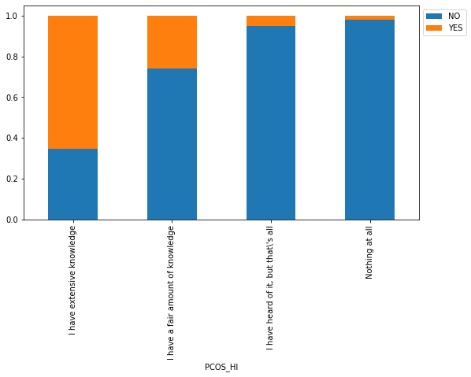

```python
fig = stacked_barplot(data1, "PCOS_HI", "TREATMENT")
# fig.figure.savefig("know-treatment.png", dpi=300, bbox_inches="tight")
```

It is observed that the amount of knowledge is directly proportional to the number of people seeking treatment. It is advisable to increase awareness to that more people get checked and get treated.

### Observations on MENSES vs. TREATMENT:

```
TREATMENT    NO  YES   All
MENSES
All        1128  273  1401
YES        1100  263  1363
NO           28   10    38
------------------------------------------------------------------------------------------------------------------------
```

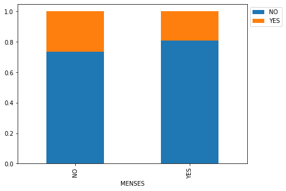

```python
fig = stacked_barplot(data1, "MENSES", "TREATMENT")
# fig.figure.savefig("mens_treat.png", dpi=300, bbox_inches="tight")
```

More non-menstruating women seek treatment though not significantly more than those who menstruate.

### Observations on AGE vs. MENSES:

```
MENSES  NO   YES   All
AGE
All     38  1363  1401
18-24   16   581   597
25-34   11   621   632
35-44    6   142   148
45-54    5    19    24
------------------------------------------------------------------------------------------------------------------------
```

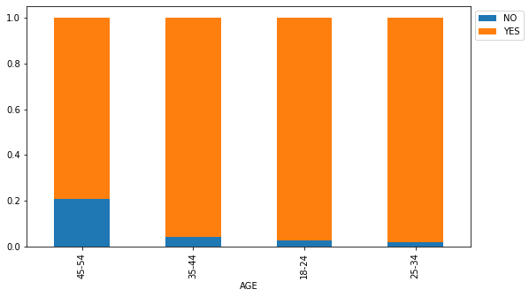

```python
fig = stacked_barplot(data1, "AGE", "MENSES")
# fig.figure.savefig("age-mens.png", dpi=300, bbox_inches="tight")
```

More attention should be on the respondents of reproductive age that do not menstruate.

### Let's extract and create a new dataframe consisiting of respondents that do not menstruate:

```python
# Create a new dataframe of respondents that do no menstruate
dm = data1[data1["MENSES"] == "NO"]
```

### Analyse the new dataframe:

```
TREATMENT  NO  YES  All
MENSES
NO         28   10   38
All        28   10   38
------------------------------------------------------------------------------------------------------------------------
```

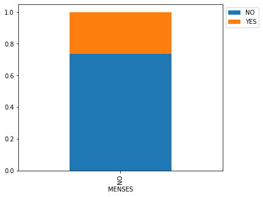

```python
fig = stacked_barplot(dm, "MENSES", "TREATMENT")
# fig.figure.savefig("mens_treat2.png", dpi=300, bbox_inches="tight")
```

Less than 30% of respondents that do not menstruate have sought treatment. Let's have a look at other dependencies.

```
AGE     18-24  25-34  35-44  45-54  All
MENSES
NO         16     11      6      5   38
All        16     11      6      5   38
------------------------------------------------------------------------------------------------------------------------
```

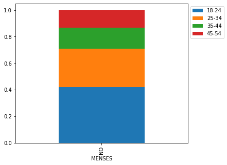

```python
fig = stacked_barplot(dm, "MENSES", "AGE")
# fig.figure.savefig("menses_age2.png", dpi=300, bbox_inches="tight")
```

Over 40% are aged 18-24.

```
MONTHLY_INCOME  0 - 30,000  151,000 - 300,000  301,000 and above  \
MENSES
NO                       7                  5                 12
All                      7                  5                 12

MONTHLY_INCOME  31,000 - 75,000  76,000 - 150,000  All
MENSES
NO                           12                 2   38
All                          12                 2   38
------------------------------------------------------------------------------------------------------------------------
```

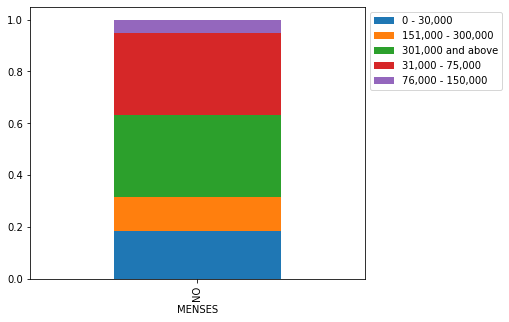

```python
fig = stacked_barplot(dm, "MENSES", "MONTHLY_INCOME")
# fig.figure.savefig("mens_income2.png", dpi=300, bbox_inches="tight")
```

A third of respondents are high income earners and another third are in the second lowest group.

```
S1_GRP  0-3  4-7  8-11  All
MENSES
NO       21   14     3   38
All      21   14     3   38
------------------------------------------------------------------------------------------------------------------------
```

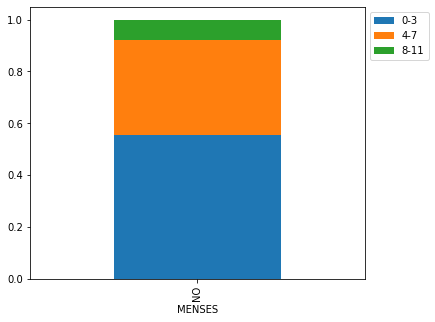

```python
fig = stacked_barplot(dm, "MENSES", "S1_GRP")
# fig.figure.savefig("menses_sy1.png", dpi=300, bbox_inches="tight")
```

```
S2_GRP  0-2  3-5  6-8  All
MENSES
NO       10   19    9   38
All      10   19    9   38
------------------------------------------------------------------------------------------------------------------------
```

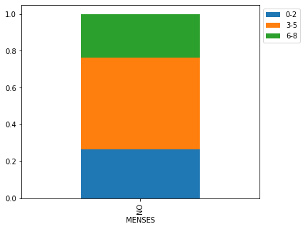

```python
fig = stacked_barplot(dm, "MENSES", "S2_GRP")
# fig.figure.savefig("menses_sy2.png", dpi=300, bbox_inches="tight")
```

For SYMPTOMS_1, 55% of the respondents identified 0-3 symptoms while for SYMPTOMS_2, 50% identified 3-5 symptoms.

```
PCOS_HI  I have a fair amount of knowledge  I have extensive knowledge  \
MENSES
NO                                      10                           8
All                                     10                           8

PCOS_HI  I have heard of it, but that\'s all  Nothing at all  All
MENSES
NO                                        10              10   38
All                                       10              10   38
------------------------------------------------------------------------------------------------------------------------
```

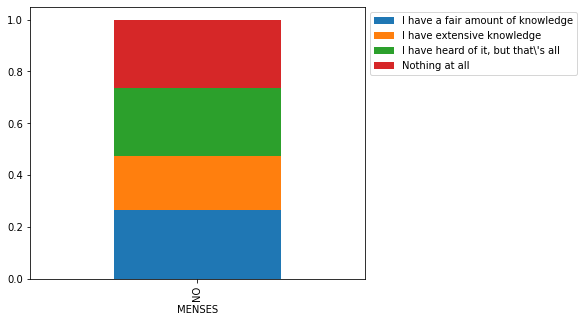

```python
fig = stacked_barplot(dm, "MENSES", "PCOS_HI")
# fig.figure.savefig("menses_pchi.png", dpi=300, bbox_inches="tight")
```

It's an almost uniform distribution of knowledge of PCOS within this portion of respondents.

```
EDUCATION          None  Primary School  Secondary School  \
MONTHLY_INCOME
76,000 - 150,000      3               1                 2
All                  10               1                43
0 - 30,000            1               0                27
151,000 - 300,000     0               0                 2
301,000 and above     0               0                 2
31,000 - 75,000       6               0                10

EDUCATION          Tertiary Institutions   All
MONTHLY_INCOME
76,000 - 150,000                     285   291
All                                 1347  1401
0 - 30,000                           397   425
151,000 - 300,000                    176   178
301,000 and above                    197   199
31,000 - 75,000                      292   308
------------------------------------------------------------------------------------------------------------------------
```

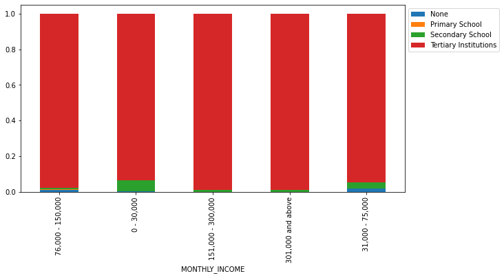

```python
fig = stacked_barplot(data1, "MONTHLY_INCOME", "EDUCATION")
# fig.figure.savefig("income-ed.png", dpi=300, bbox_inches="tight")
```

```
MENSES  NO   YES   All
AGE
All     38  1363  1401
18-24   16   581   597
25-34   11   621   632
35-44    6   142   148
45-54    5    19    24
------------------------------------------------------------------------------------------------------------------------
```

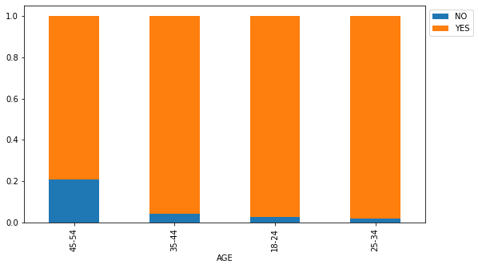

```python
fig = stacked_barplot(data1, "AGE", "MENSES")
# fig.figure.savefig("menses-age.png", dpi=300, bbox_inches="tight")
```

```
MONTHLY_INCOME                         0 - 30,000  151,000 - 300,000  \
TREATMENT_FACILITY
All                                            86                 43
Conventional means(Hospitals/Clinics)          62                 32
Both                                           15                  9
Alternative means                               9                  2

MONTHLY_INCOME                         301,000 and above  31,000 - 75,000  \
TREATMENT_FACILITY
All                                                   81               70
Conventional means(Hospitals/Clinics)                 57               48
Both                                                  20               17
Alternative means                                      4                5

MONTHLY_INCOME                         76,000 - 150,000  All
TREATMENT_FACILITY
All                                                  78  358
Conventional means(Hospitals/Clinics)                45  244
Both                                                 27   88
Alternative means                                     6   26
------------------------------------------------------------------------------------------------------------------------
```

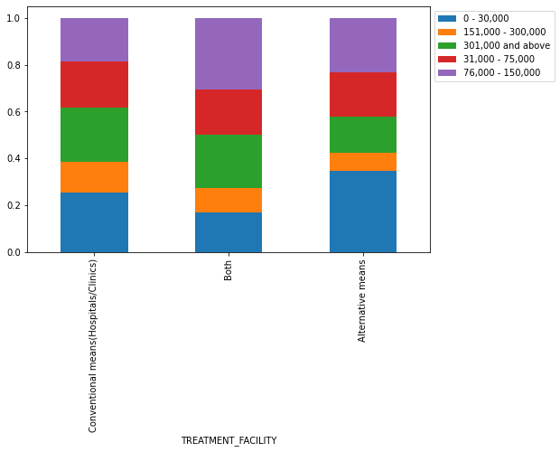

```python
fig = stacked_barplot(data1, "TREATMENT_FACILITY", "MONTHLY_INCOME")
# fig.figure.savefig("facility-income.png", dpi=300, bbox_inches="tight")
```

```
TREATMENT_FACILITY  Alternative means  Both  \
AFFORDABILITY
All                                26    88
No response                        11     9
1.0                                 6    24
3.0                                 4    24
4.0                                 2     7
5.0                                 2     4
2.0                                 1    20

TREATMENT_FACILITY  Conventional means(Hospitals/Clinics)  All
AFFORDABILITY
All                                                   244  358
No response                                            23   43
1.0                                                    54   84
3.0                                                    75  103
4.0                                                    24   33
5.0                                                    14   20
2.0                                                    54   75
------------------------------------------------------------------------------------------------------------------------
```

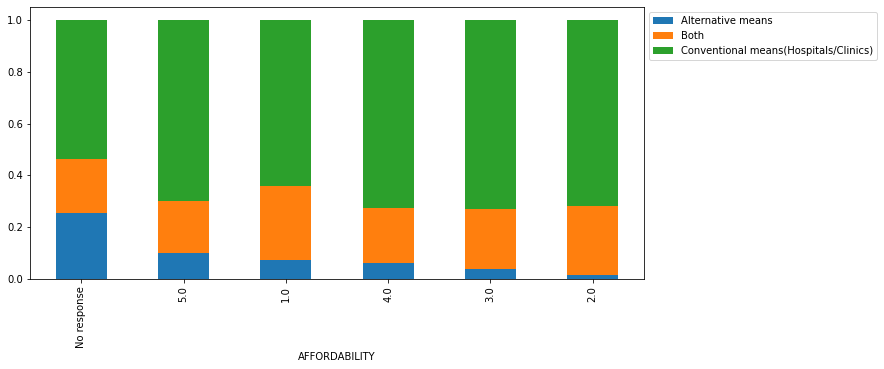

```python
fig = stacked_barplot(data1, "AFFORDABILITY", "TREATMENT_FACILITY")
# fig.figure.savefig("facility-afford.png", dpi=300, bbox_inches="tight")
```

```
MEDICINE_PURCHASE  Online purchase (International outlets)  \
AFFORDABILITY
All                                                     24
2.0                                                      3
1.0                                                      8
3.0                                                      5
4.0                                                      4
5.0                                                      2
No response                                              2

MEDICINE_PURCHASE  Online purchase (Nigerian outlets)  \
AFFORDABILITY
All                                                 7
2.0                                                 2
1.0                                                 4
3.0                                                 1
4.0                                                 0
5.0                                                 0
No response                                         0

MEDICINE_PURCHASE  Online purchase (Nigerian outlets)\nOnline purchase (International outlets)  \
AFFORDABILITY
All                                                                4
2.0                                                                3
1.0                                                                1
3.0                                                                0
4.0                                                                0
5.0                                                                0
No response                                                        0

MEDICINE_PURCHASE  Walk-in pharmacy/supermarket  \
AFFORDABILITY
All                                         250
2.0                                          58
1.0                                          53
3.0                                          89
4.0                                          24
5.0                                          19
No response                                   7

```

[output cut: 25 more lines]

```
3.0                                                                1
4.0                                                                0
5.0                                                                0
No response                                                        0

MEDICINE_PURCHASE  All
AFFORDABILITY
All                311
2.0                 72
1.0                 79
3.0                100
4.0                 30
5.0                 21
No response          9
------------------------------------------------------------------------------------------------------------------------
```

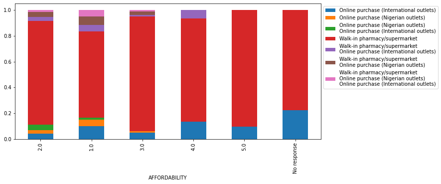

```python
fig = stacked_barplot(data1, "AFFORDABILITY", "MEDICINE_PURCHASE")
# fig.figure.savefig("afford-meds.png", dpi=300, bbox_inches="tight")
```

```
TREATMENT                                           NO  YES  All
MEDICINE_PURCHASE
All                                                 63  248  311
Walk-in pharmacy/supermarket                        51  199  250
Online purchase (International outlets)              5   19   24
Walk-in pharmacy/supermarket\nOnline purchase (...   1   10   11
Online purchase (Nigerian outlets)                   1    6    7
Walk-in pharmacy/supermarket\nOnline purchase (...   3    6    9
Walk-in pharmacy/supermarket\nOnline purchase (...   0    6    6
Online purchase (Nigerian outlets)\nOnline purc...   2    2    4
------------------------------------------------------------------------------------------------------------------------
```

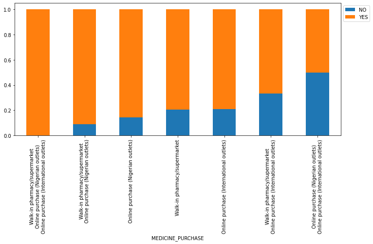

```python
fig = stacked_barplot(data1, "MEDICINE_PURCHASE", "TREATMENT")
# fig.figure.savefig("treat-meds.png", dpi=300, bbox_inches="tight")
```